# Regression diagnostics: SHIN checks for linear regression

Reading check_model() diagnostic plots for simple and multiple linear regression

RSR Resources

2026-07-08

# Setup

```r
if (!require(pacman)) install.packages("pacman")
pacman::p_load(tidyverse, performance, qqplotr)
```

## SUNSHINE and SHIN

We created an acronym (SUNSHINE) to help you remember the eight checks you should keep in mind when fitting a linear regression model.

- **S** (**Sample size**): do you have enough observations for the model?
- **U** (**Uncorrelated errors**): are the residuals uncorrelated across observations (no patterns by time or space order)?
- **N** (**No multicollinearity**): are the predictors free of strong correlations with each other?
- **S** (**Shape / linearity**): is the relationship actually a straight line?
- **H** (**Homogeneity of variance**): does the spread of residuals stay constant?
- **I** (**Influential points**): is the fit stable if you drop any single point?
- **N** (**Normality of residuals**): are the prediction errors roughly bell-shaped?
- **E** (**Exogeneity**): are the predictors unrelated to anything the model left out?

This script covers six checks you can run in R, in acronym order: **U** (uncorrelated errors, via a residuals-in-order plot and `check_autocorrelation()`), **N** (no multicollinearity, via `check_collinearity()`), and the four **SHIN** checks (via `check_model()`).

## A note on statistical tests

`check_heteroscedasticity()`, `check_outliers()`, and `check_normality()` are available, but we only run them when a plot already looks problematic. With moderate to large samples these tests flag trivial departures, so do not run them on every model. Each section also mentions one common fix for a violation.

# Diagnostic checks

Each section walks through one check: good example, bad example, practice question.

## U: Uncorrelated errors

**The question:** is the residual for one observation unrelated to the residual for another?

Correlated errors usually come from the structure of the data. The two common cases are:

- **Time-ordered data (autocorrelation):** observations collected in sequence, where nearby time points have similar residuals. This is the case we work through below.
- **Clustered data:** observations grouped by site, clinic, school, or family, where members of the same group resemble each other. This needs a multilevel (mixed-effects) model and is not covered in this script.

`check_model()` has no panel for this assumption, because the diagnostic depends on knowing the collection order or grouping. For time-ordered data, the visual check is to plot the residuals in collection order and look for runs: long stretches of positive residuals followed by long stretches of negative ones.

### ED visits and pollution, unrelated days (uncorrelated errors)

Daily emergency department visits vs. daily air pollution, for 30 days sampled from different, unrelated periods.

```r
uncorr_good <- data.frame(
  day       = 1:30,
  pollution = c(75, 76, 37, 70, 59, 51, 64, 28, 59, 62, 47, 63, 76, 35, 48, 76, 79, 27, 48, 54, 74, 28, 79, 77, 25, 51, 43, 74, 47, 70),
  visits    = c(39, 37, 18, 29, 37, 29, 29, 23, 36, 39, 28, 33, 33, 27, 27, 39, 41, 26, 28, 33, 32, 21, 36, 31, 23, 31, 27, 39, 27, 32)
)
```

```r
uncorr_good_model <- lm(visits ~ pollution, data = uncorr_good)
summary(uncorr_good_model)
```

```
##
## Call:
## lm(formula = visits ~ pollution, data = uncorr_good)
##
## Residuals:
##     Min      1Q  Median      3Q     Max
## -7.5918 -1.9955 -0.1807  2.7418  6.5566
##
## Coefficients:
##             Estimate Std. Error t value Pr(>|t|)
## (Intercept) 15.45143    2.17574   7.102  1.0e-07 ***
## pollution    0.27406    0.03669   7.470  3.9e-08 ***
## ---
## Signif. codes:  0 '***' 0.001 '**' 0.01 '*' 0.05 '.' 0.1 ' ' 1
##
## Residual standard error: 3.468 on 28 degrees of freedom
## Multiple R-squared:  0.6659, Adjusted R-squared:  0.6539
## F-statistic:  55.8 on 1 and 28 DF,  p-value: 3.898e-08
```

Plot the residuals in collection order:

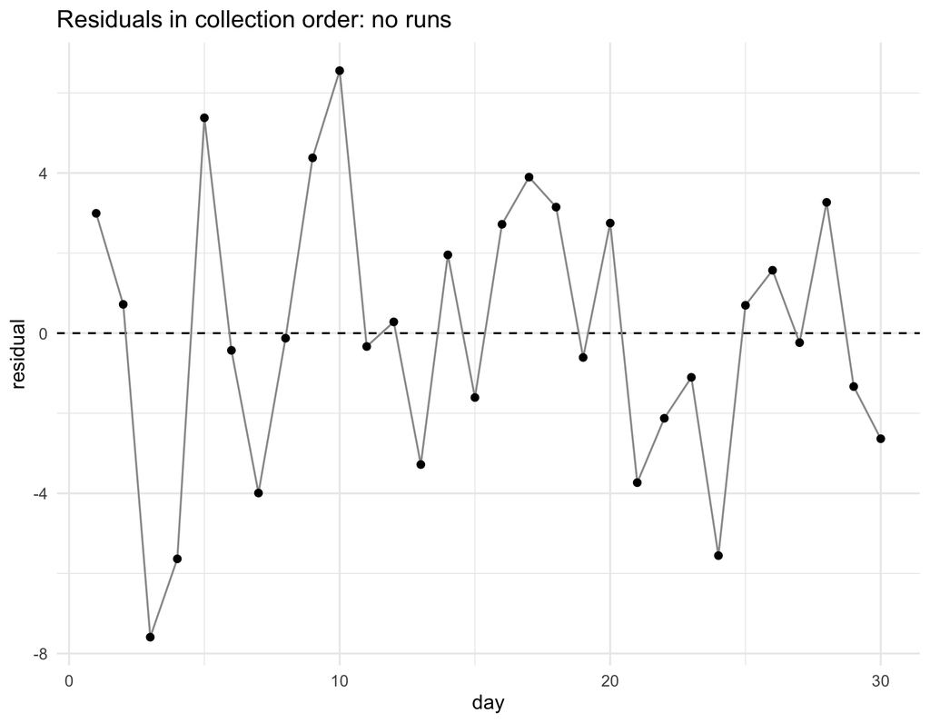

```r
uncorr_good %>%
  mutate(residual = resid(uncorr_good_model)) %>%
  ggplot(aes(day, residual)) +
  geom_hline(yintercept = 0, linetype = "dashed") +
  geom_line(colour = "grey60") +
  geom_point(size = 2) +
  labs(title = "Residuals in collection order: no runs") +
  theme_minimal(base_size = 14)
```

The residuals bounce back and forth across zero with no long runs. Knowing one day’s residual tells you nothing about the next day’s.

### ED visits and pollution, consecutive days (autocorrelated errors)

The same kind of data, but now 60 **consecutive** days from one city. Other slow-moving influences on visits (for example, a flu wave passing through) are not in the model, so several days in a row sit above the line, then several days in a row sit below it.

```r
uncorr_bad <- data.frame(
  day       = 1:60,
  pollution = c(61, 37, 43, 48, 45, 47, 61, 54, 55, 71, 54, 71, 64, 46, 55, 41, 27, 29, 29, 35, 32, 31, 36, 15, 37, 30, 37, 39, 29, 38, 36, 52, 50, 51, 50, 50, 63, 46, 53, 56, 61, 43, 44, 33, 37, 34, 45, 36, 30, 34, 24, 25, 28, 39, 33, 33, 19, 36, 38, 33),
  visits    = c(26, 22, 29, 28, 29, 30, 36, 32, 35, 35, 29, 34, 34, 30, 32, 25, 22, 19, 22, 27, 28, 27, 27, 22, 29, 28, 27, 31, 24, 30, 31, 35, 30, 34, 35, 33, 38, 36, 38, 38, 34, 31, 29, 28, 31, 30, 35, 29, 28, 30, 27, 29, 25, 26, 25, 25, 22, 27, 25, 25)
)
```

```r
uncorr_bad_model <- lm(visits ~ pollution, data = uncorr_bad)
summary(uncorr_bad_model)
```

```
##
## Call:
## lm(formula = visits ~ pollution, data = uncorr_bad)
##
## Residuals:
##     Min      1Q  Median      3Q     Max
## -8.4661 -1.8678 -0.4652  2.1690  5.6883
##
## Coefficients:
##             Estimate Std. Error t value Pr(>|t|)
## (Intercept) 18.03872    1.35394  13.323  < 2e-16 ***
## pollution    0.26930    0.03104   8.675 4.57e-12 ***
## ---
## Signif. codes:  0 '***' 0.001 '**' 0.01 '*' 0.05 '.' 0.1 ' ' 1
##
## Residual standard error: 2.981 on 58 degrees of freedom
## Multiple R-squared:  0.5648, Adjusted R-squared:  0.5573
## F-statistic: 75.26 on 1 and 58 DF,  p-value: 4.57e-12
```

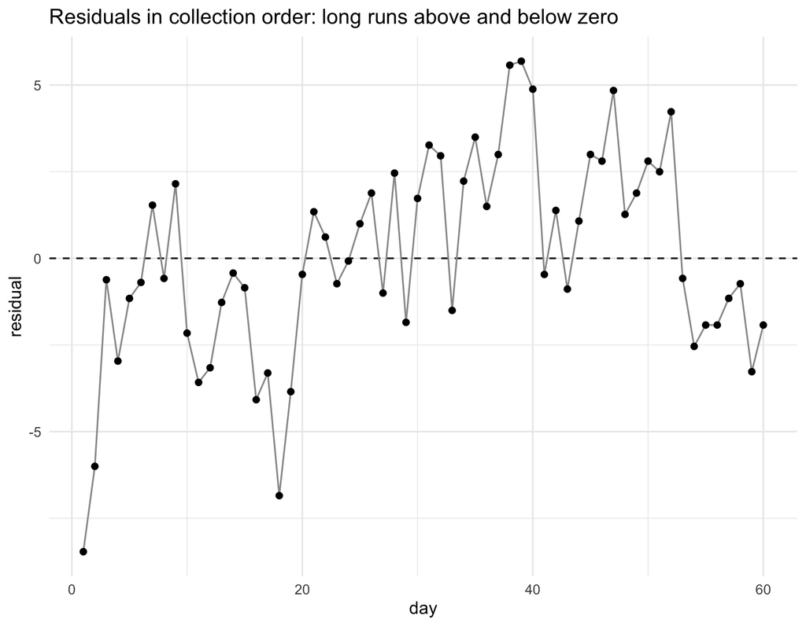

```r
uncorr_bad %>%
  mutate(residual = resid(uncorr_bad_model)) %>%
  ggplot(aes(day, residual)) +
  geom_hline(yintercept = 0, linetype = "dashed") +
  geom_line(colour = "grey60") +
  geom_point(size = 2) +
  labs(title = "Residuals in collection order: long runs above and below zero") +
  theme_minimal(base_size = 14)
```

The residuals form waves: runs of days above zero, then runs below. Each day’s residual resembles the previous day’s.

Because the plot already shows the pattern, we can run the formal test to confirm. `check_autocorrelation()` runs a **Durbin-Watson test** under the hood:

```r
check_autocorrelation(uncorr_bad_model)
```

[output not shown]

The consequence of autocorrelated errors is that the model treats the 60 days as 60 independent pieces of information when they carry less than that, so standard errors are too small, confidence intervals too narrow, and p-values too small.

**One way to fix it:** add the time structure to the model, for example by including the missing time-varying variable (here, something tracking the flu wave) or terms for time itself. More formal options are time-series models or Newey-West standard errors, but adding the omitted time variable is the most common first step.

### Practice

Weekly influenza-like illness cases at a clinic vs. average weekly temperature, over 40 consecutive weeks.

Fit the model, plot the residuals in collection order, and decide whether the errors look uncorrelated. If the plot suggests a problem, confirm with `check_autocorrelation()`.

```r
practice_10 <- data.frame(
  week  = 1:40,
  temp  = c(22.2, 24.1, 25.5, 22.7, 25.2, 24.4, 23.8, 25, 19.2, 22.9, 17.5, 15.3, 14.6, 14.9, 13.2, 10.8, 8, 7.4, 10, 7, 4.7, 3.4, 4.6, 1.7, 4.3, 4.2, 8.7, 9.3, 8.2, 7.3, 12.8, 14.2, 15.5, 17, 16.4, 20, 22.6, 21.4, 20.5, 25),
  cases = c(68, 62, 61, 66, 65, 69, 74, 73, 87, 67, 77, 84, 84, 81, 84, 98, 101, 100, 94, 103, 109, 112, 102, 111, 108, 106, 98, 93, 98, 97, 75, 79, 80, 77, 86, 68, 62, 53, 64, 49)
)
```

```r
practice_10_model <- lm(cases ~ temp, data = practice_10)
summary(practice_10_model)
```

```
##
## Call:
## lm(formula = cases ~ temp, data = practice_10)
##
## Residuals:
##      Min       1Q   Median       3Q      Max
## -15.9886  -2.3388   0.2584   2.7967  13.2359
##
## Coefficients:
##             Estimate Std. Error t value Pr(>|t|)
## (Intercept) 115.4405     2.1110   54.69   <2e-16 ***
## temp         -2.1706     0.1271  -17.09   <2e-16 ***
## ---
## Signif. codes:  0 '***' 0.001 '**' 0.01 '*' 0.05 '.' 0.1 ' ' 1
##
## Residual standard error: 5.928 on 38 degrees of freedom
## Multiple R-squared:  0.8848, Adjusted R-squared:  0.8818
## F-statistic: 291.9 on 1 and 38 DF,  p-value: < 2.2e-16
```

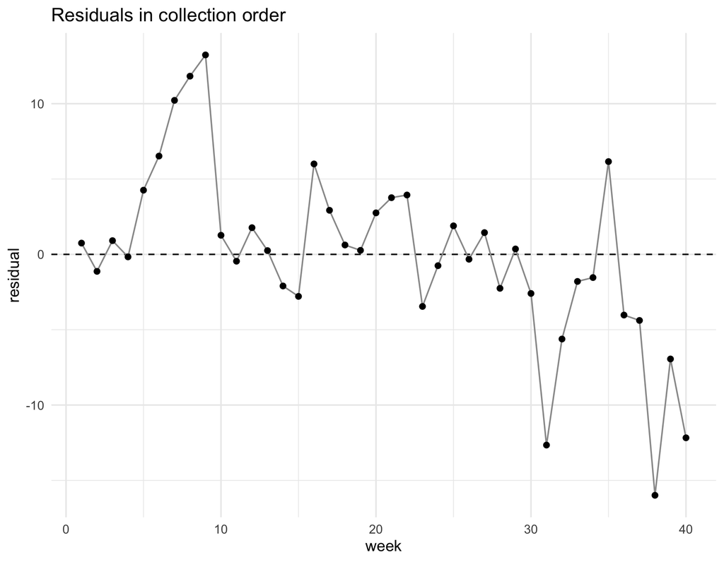

```r
practice_10 %>%
  mutate(residual = resid(practice_10_model)) %>%
  ggplot(aes(week, residual)) +
  geom_hline(yintercept = 0, linetype = "dashed") +
  geom_line(colour = "grey60") +
  geom_point(size = 2) +
  labs(title = "Residuals in collection order") +
  theme_minimal(base_size = 14)
```

```r
check_autocorrelation(practice_10_model)
```

**Your answer here:**

## N: No multicollinearity

**The question:** are the predictors free of strong correlations with each other?

This check only applies when you have two or more predictors. Use `check_collinearity()`; **VIF** (**variance inflation factor**) values close to 1 are fine, and values above about 5 suggest problematic overlap. For a fuller explanation of VIF, see [this video](https://www.youtube.com/watch?v=GMAp_tP1ZQ0).

### Resting heart rate from lifestyle factors (low multicollinearity)

Predict **resting heart rate** (bpm) from weekly **exercise hours**, nightly **sleep hours**, and daily **caffeine intake** (mg). These predictors measure different aspects of lifestyle, so they should not overlap much.

```r
mlr_col_good <- data.frame(
  exercise_h = c(2.5, 8.3, 4.5, 3.9, 6.4, 6.4, 2.1, 3.7, 6.2, 6.7, 5.6, 5.5, 5.8, 6, 8.8, 8.5, 2, 7.3, 9.1, 3.5, 3.1, 1.1, 2.2, 1.8, 3.1, 8.1, 6.4, 9.2, 6, 7.8, 4.4, 4.4, 2.5, 5.1, 3.3, 4, 9, 2.8, 6.2, 2.9, 3.5, 8.1, 2.6, 6.1, 4.8, 3.4, 1.4, 1.9, 3.8, 8.2),
  sleep_h = c(5.9, 5.9, 8.5, 9, 8.4, 8.6, 6.9, 5.9, 5.5, 6.1, 8.3, 5.2, 8.2, 5.4, 8.1, 6.2, 8.1, 7.2, 6.4, 5.4, 8, 8, 8.6, 8.9, 7.1, 7.2, 5.7, 5.7, 8.1, 8, 8.1, 7.6, 6.5, 5, 8.8, 8.4, 5.9, 7, 7.5, 8.7, 5, 6.1, 6.7, 8.3, 8.5, 6, 6.3, 6.2, 5.7, 7.7),
  caffeine_mg = c(307, 273, 84, 285, 242, 136, 16, 161, 32, 125, 130, 31, 60, 61, 365, 281, 328, 266, 86, 185, 287, 329, 328, 80, 240, 172, 255, 168, 352, 128, 126, 197, 135, 89, 332, 215, 39, 44, 230, 215, 195, 128, 272, 345, 339, 107, 242, 332, 237, 80),
  resting_hr = c(71, 65, 62, 61, 61, 65, 63, 67, 64, 63, 61, 62, 57, 63, 58, 58, 65, 60, 60, 65, 66, 68, 69, 67, 66, 61, 62, 62, 65, 61, 64, 64, 60, 61, 67, 62, 56, 62, 67, 63, 65, 59, 68, 64, 64, 60, 70, 71, 65, 59)
)
```

```r
mlr_col_good_model <- lm(resting_hr ~ exercise_h + sleep_h + caffeine_mg, data = mlr_col_good)
summary(mlr_col_good_model)
```

```
##
## Call:
## lm(formula = resting_hr ~ exercise_h + sleep_h + caffeine_mg,
##     data = mlr_col_good)
##
## Residuals:
##     Min      1Q  Median      3Q     Max
## -5.2534 -1.6253  0.2116  1.5405  4.5267
##
## Coefficients:
##              Estimate Std. Error t value Pr(>|t|)
## (Intercept) 69.442311   2.211677  31.398  < 2e-16 ***
## exercise_h  -0.926732   0.145660  -6.362 8.27e-08 ***
## sleep_h     -0.561435   0.287471  -1.953 0.056917 .
## caffeine_mg  0.013165   0.003442   3.825 0.000393 ***
## ---
## Signif. codes:  0 '***' 0.001 '**' 0.01 '*' 0.05 '.' 0.1 ' ' 1
##
## Residual standard error: 2.34 on 46 degrees of freedom
## Multiple R-squared:  0.5829, Adjusted R-squared:  0.5557
## F-statistic: 21.43 on 3 and 46 DF,  p-value: 7.846e-09
```

```r
check_collinearity(mlr_col_good_model)
```

| Term | VIF | VIF_CI_low | VIF_CI_high | SE_factor | Tolerance | Tolerance_CI_low | Tolerance_CI_high |
| --- | --- | --- | --- | --- | --- | --- | --- |
| exercise_h | 1.050423 | 1.000254 | 11.011001 | 1.024901 | 0.9519974 | 0.09081826 | 0.9997461 |
| sleep_h | 1.122257 | 1.010372 | 2.441017 | 1.059366 | 0.8910614 | 0.40966532 | 0.9897341 |
| caffeine_mg | 1.138208 | 1.014740 | 2.295897 | 1.066868 | 0.8785741 | 0.43555953 | 0.9854742 |

All VIF values are close to 1, which is what you want. Each predictor carries distinct information.

### BMI percentile from age, grade, and parent income (multicollinearity)

Predict each child’s **BMI percentile** from **age** (years), **grade** (school year), and **parent income bracket** (1 = lowest, 5 = highest):

`bmi_pct ~ age_years + grade + income_bracket`

Age and grade overlap: older children are usually in higher grades, so both predictors carry much of the same school-age information. Parent income bracket is more distinct.

```r
mlr_col_bad <- data.frame(
  age_years = c(6, 10, 6, 6, 7, 9, 7, 7, 6, 12, 12, 9, 6, 10, 11, 9, 7, 7, 12, 8, 6, 6, 8, 9, 10, 12, 10, 10, 9, 7, 9, 8, 7, 6, 7, 11, 8, 12, 11, 7, 9, 9, 11, 7, 10, 9, 10, 9, 7, 7),
  grade = c(2, 6, 1, 1, 2, 4, 2, 2, 1, 6, 6, 3, 1, 6, 6, 4, 2, 1, 6, 2, 2, 1, 3, 3, 4, 6, 6, 6, 3, 1, 4, 2, 2, 1, 2, 5, 3, 6, 6, 3, 3, 3, 6, 2, 5, 5, 4, 3, 2, 3),
  income_bracket = c(4, 5, 1, 4, 1, 1, 5, 3, 1, 2, 5, 1, 5, 5, 1, 2, 3, 2, 2, 1, 3, 1, 5, 1, 3, 1, 3, 5, 1, 1, 2, 2, 4, 4, 2, 2, 4, 4, 2, 1, 1, 2, 2, 1, 4, 3, 5, 2, 4, 2),
  bmi_pct = c(78.7, 83.4, 72.7, 70.8, 79, 70.1, 95.2, 82.4, 57.6, 86.3, 92.8, 59, 83.7, 104.8, 84.7, 81.9, 68.7, 69.9, 83.5, 84.1, 65.5, 65.4, 92.1, 76.7, 88.6, 79.5, 102.6, 87, 69.3, 77, 87, 65.8, 74.7, 71.9, 69.4, 74.3, 99.3, 90.2, 72.6, 55.8, 80.8, 76.6, 78.6, 71.2, 76.2, 84.4, 88.6, 90.7, 70.1, 69.9)
)
```

```r
mlr_col_bad_model <- lm(bmi_pct ~ age_years + grade + income_bracket, data = mlr_col_bad)
summary(mlr_col_bad_model)
```

```
##
## Call:
## lm(formula = bmi_pct ~ age_years + grade + income_bracket, data = mlr_col_bad)
##
## Residuals:
##     Min      1Q  Median      3Q     Max
## -14.722  -5.598  -1.698   5.761  18.541
##
## Coefficients:
##                Estimate Std. Error t value Pr(>|t|)
## (Intercept)     47.9955    10.1807   4.714 2.28e-05 ***
## age_years        2.3946     1.7413   1.375    0.176
## grade            0.1363     1.8723   0.073    0.942
## income_bracket   3.7664     0.8638   4.361 7.24e-05 ***
## ---
## Signif. codes:  0 '***' 0.001 '**' 0.01 '*' 0.05 '.' 0.1 ' ' 1
##
## Residual standard error: 8.31 on 46 degrees of freedom
## Multiple R-squared:  0.4648, Adjusted R-squared:  0.4299
## F-statistic: 13.32 on 3 and 46 DF,  p-value: 2.189e-06
```

```r
check_collinearity(mlr_col_bad_model)
```

| Term | VIF | VIF_CI_low | VIF_CI_high | SE_factor | Tolerance | Tolerance_CI_low | Tolerance_CI_high |
| --- | --- | --- | --- | --- | --- | --- | --- |
| age_years | 8.004906 | 5.167506 | 12.77412 | 2.829294 | 0.1249234 | 0.07828329 | 0.1935170 |
| grade | 8.212049 | 5.295010 | 13.11025 | 2.865667 | 0.1217723 | 0.07627618 | 0.1888571 |
| income_bracket | 1.142810 | 1.016116 | 2.26548 | 1.069023 | 0.8750360 | 0.44140747 | 0.9841394 |

The VIF values for `age_years` and `grade` are around 8, flagged as moderate overlap. `income_bracket` is fine on its own.

**One way to fix it:** drop one of the overlapping predictors (for example, keep grade and drop age).

### Practice

A researcher fits:

`peak_flow ~ height_cm + weight_kg + age_years + bmi`

Fit the model below and run `check_collinearity()`. Which predictors show problematic overlap?

```r
practice_9 <- data.frame(
  height_cm = c(157, 175, 179, 162, 159, 156, 159, 171, 156, 155, 165, 175, 164, 165, 162, 166, 166, 169, 172, 158, 160, 175, 157, 173, 160, 162, 168, 160, 166, 172),
  weight_kg = c(58, 81, 81, 78, 72, 83, 74, 80, 63, 64, 71, 69, 84, 57, 80, 53, 63, 52, 55, 77, 64, 63, 65, 61, 69, 84, 70, 70, 72, 79),
  age_years = c(51, 40, 59, 44, 35, 31, 30, 51, 37, 52, 36, 50, 46, 38, 36, 58, 53, 50, 31, 54, 44, 56, 29, 33, 50, 34, 27, 56, 38, 29),
  bmi = c(23.5, 26.4, 25.3, 29.7, 28.5, 34.1, 29.3, 27.4, 25.9, 26.6, 26.1, 22.5, 31.2, 20.9, 30.5, 19.2, 22.9, 18.2, 18.6, 30.8, 25, 20.6, 26.4, 20.4, 27, 32, 24.8, 27.3, 26.1, 26.7),
  peak_flow = c(503, 529, 548, 528, 504, 512, 513, 539, 532, 480, 533, 543, 504, 510, 526, 514, 529, 528, 531, 519, 520, 559, 474, 547, 525, 516, 533, 500, 521, 539)
)
```

```r
practice_9_model <- lm(peak_flow ~ height_cm + weight_kg + age_years + bmi, data = practice_9)
summary(practice_9_model)
```

```
##
## Call:
## lm(formula = peak_flow ~ height_cm + weight_kg + age_years +
##     bmi, data = practice_9)
##
## Residuals:
##     Min      1Q  Median      3Q     Max
## -29.015  -7.366  -0.046   6.572  31.982
##
## Coefficients:
##               Estimate Std. Error t value Pr(>|t|)
## (Intercept) -564.10435  497.86684  -1.133   0.2679
## height_cm      6.48934    2.98597   2.173   0.0394 *
## weight_kg     -5.05408    3.50813  -1.441   0.1621
## age_years      0.06091    0.24454   0.249   0.8053
## bmi           14.20616    9.59760   1.480   0.1513
## ---
## Signif. codes:  0 '***' 0.001 '**' 0.01 '*' 0.05 '.' 0.1 ' ' 1
##
## Residual standard error: 12.69 on 25 degrees of freedom
## Multiple R-squared:  0.6095, Adjusted R-squared:  0.547
## F-statistic: 9.755 on 4 and 25 DF,  p-value: 6.775e-05
```

```r
check_collinearity(practice_9_model)
```

| Term | VIF | VIF_CI_low | VIF_CI_high | SE_factor | Tolerance | Tolerance_CI_low | Tolerance_CI_high |
| --- | --- | --- | --- | --- | --- | --- | --- |
| height_cm | 73.919633 | 43.073230 | 127.381382 | 8.597653 | 0.013528206 | 0.007850441 | 0.023216276 |
| weight_kg | 206.227036 | 119.698315 | 355.833480 | 14.360607 | 0.004849025 | 0.002810303 | 0.008354336 |
| age_years | 1.093905 | 1.002968 | 3.971264 | 1.045899 | 0.914155924 | 0.251809017 | 0.997040953 |
| bmi | 278.509967 | 161.560644 | 480.642958 | 16.688618 | 0.003590536 | 0.002080546 | 0.006189626 |

**Your answer here:**

## S: Shape (Linearity)

**The question:** is the relationship actually a straight line?

For **simple linear regression**, you can often spot a curved pattern in a scatterplot of the outcome versus the single predictor. That is why the examples below start with a scatterplot.

So why bother with the **Linearity** panel in `check_model()`? Two reasons. First, the diagnostic plot summarizes the pattern in the *residuals* after the line is fitted, which can make a subtle bend easier to see. Second, and more importantly for this course, **scatterplots only work when you have one continuous predictor**. As soon as you move to multiple linear regression, there is no single scatterplot that represents the whole model. The diagnostic plots are how you check shape in that setting too.

### Exercise hours and VO₂ max (linear relationship)

Weekly exercise hours vs. VO₂ max: a linear relationship.

```r
shape_good <- data.frame(
  exercise_hours = c(1, 1.5, 2, 2.5, 3, 3.5, 4, 4.5, 5, 5.5, 6, 6.5, 7, 7.5, 8, 8.5, 9, 9.5, 10, 10.5, 2, 3, 4.5, 6, 7, 8, 9, 1.5, 5, 8.5),
  vo2_max        = c(31.6, 29.4, 34.2, 30, 33.8, 30.6, 36.4, 34.2, 40, 34.8, 38.6, 35.4, 41.2, 36, 43.8, 40.6, 44.4, 41.2, 45, 41.8, 31.2, 34.8, 34.2, 40.6, 37.2, 41.8, 41.4, 32.4, 33, 42.6)
)
```

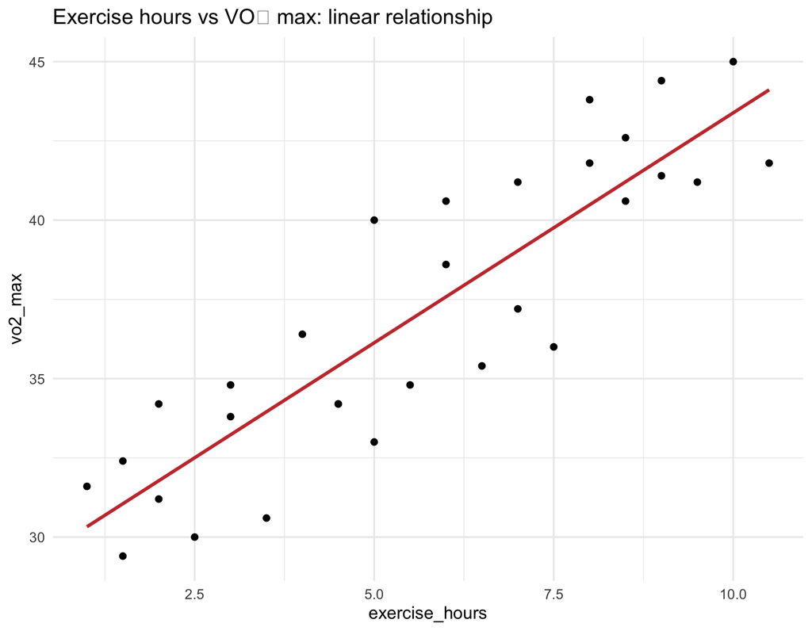

```r
ggplot(shape_good, aes(exercise_hours, vo2_max)) +
  geom_point(size = 2) +
  geom_smooth(method = "lm", se = FALSE, colour = "#C83B3B") +
  labs(title = "Exercise hours vs VO₂ max: linear relationship") +
  theme_minimal(base_size = 14)
```

```r
shape_good_model <- lm(vo2_max ~ exercise_hours, data = shape_good)
summary(shape_good_model)
```

```
##
## Call:
## lm(formula = vo2_max ~ exercise_hours, data = shape_good)
##
## Residuals:
##     Min      1Q  Median      3Q     Max
## -3.7577 -1.7871  0.0188  1.6040  3.8698
##
## Coefficients:
##                Estimate Std. Error t value Pr(>|t|)
## (Intercept)     28.8751     0.9229  31.287  < 2e-16 ***
## exercise_hours   1.4510     0.1465   9.903 1.19e-10 ***
## ---
## Signif. codes:  0 '***' 0.001 '**' 0.01 '*' 0.05 '.' 0.1 ' ' 1
##
## Residual standard error: 2.235 on 28 degrees of freedom
## Multiple R-squared:  0.7779, Adjusted R-squared:   0.77
## F-statistic: 98.07 on 1 and 28 DF,  p-value: 1.193e-10
```

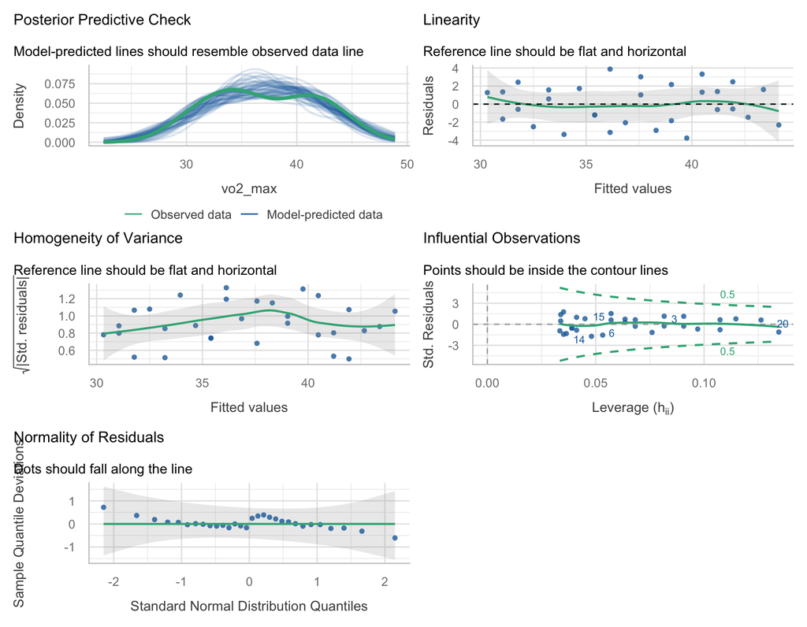

```r
check_model(shape_good_model)
```

The *Linearity* green line is flat and near zero, showing no leftover pattern.

### Study hours and quiz score (non-linear relationship)

Weekly study hours vs. quiz score.

Going from no studying to moderate studying helps a lot; extra hours past that add little because scores are near the maximum of the scale.

```r
shape_bad <- data.frame(
  study_hours = c(2, 4, 6, 9, 11, 13, 15, 17, 18, 20, 21, 23, 26, 29, 31, 34, 37, 39, 41, 43, 46, 48, 51, 53, 54, 56, 58, 60, 61, 62),
  quiz_score  = c(19.5, 30, 46.2, 55.9, 65.9, 68.3, 76.5, 76.4, 81.6, 81.3, 86.3, 84.4, 91.2, 88.8, 93, 90.4, 95.6, 92.2, 95.9, 92.6, 96.2, 92.9, 97.5, 92.9, 97.4, 93.5, 97.1, 93.4, 97.8, 93.2)
)
```

Look at the raw scatter first; you can often already see the bend.

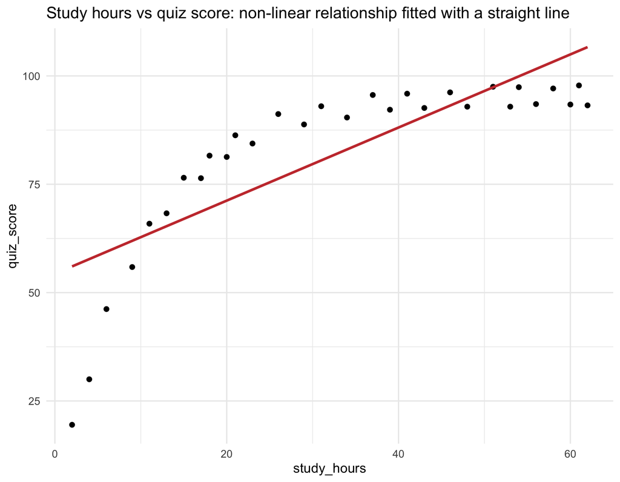

```r
ggplot(shape_bad, aes(study_hours, quiz_score)) +
  geom_point(size = 2) +
  geom_smooth(method = "lm", se = FALSE, colour = "#C83B3B") +
  labs(title = "Study hours vs quiz score: non-linear relationship fitted with a straight line") +
  theme_minimal(base_size = 14)
```

Next, inspect the diagnostic panel, especially the Linearity panel.

```r
shape_bad_model <- lm(quiz_score ~ study_hours, data = shape_bad)
summary(shape_bad_model)
```

```
##
## Call:
## lm(formula = quiz_score ~ study_hours, data = shape_bad)
##
## Residuals:
##     Min      1Q  Median      3Q     Max
## -36.540  -6.168   2.626   9.864  14.918
##
## Coefficients:
##             Estimate Std. Error t value Pr(>|t|)
## (Intercept)  54.3531     4.5660  11.904  1.8e-12 ***
## study_hours   0.8434     0.1205   7.001  1.3e-07 ***
## ---
## Signif. codes:  0 '***' 0.001 '**' 0.01 '*' 0.05 '.' 0.1 ' ' 1
##
## Residual standard error: 12.38 on 28 degrees of freedom
## Multiple R-squared:  0.6365, Adjusted R-squared:  0.6235
## F-statistic: 49.02 on 1 and 28 DF,  p-value: 1.295e-07
```

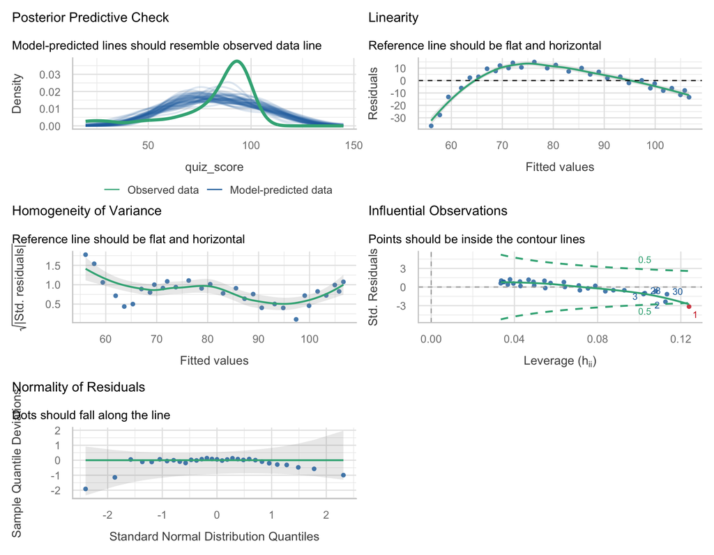

```r
check_model(shape_bad_model)
```

The green line in the *Linearity* panel arches, indicating a non-linear relationship.

**One way to fix it:** transform the predictor so the relationship becomes closer to a straight line. For a curve like this one, which rises quickly and then levels off, a log transformation of the predictor is a common choice:

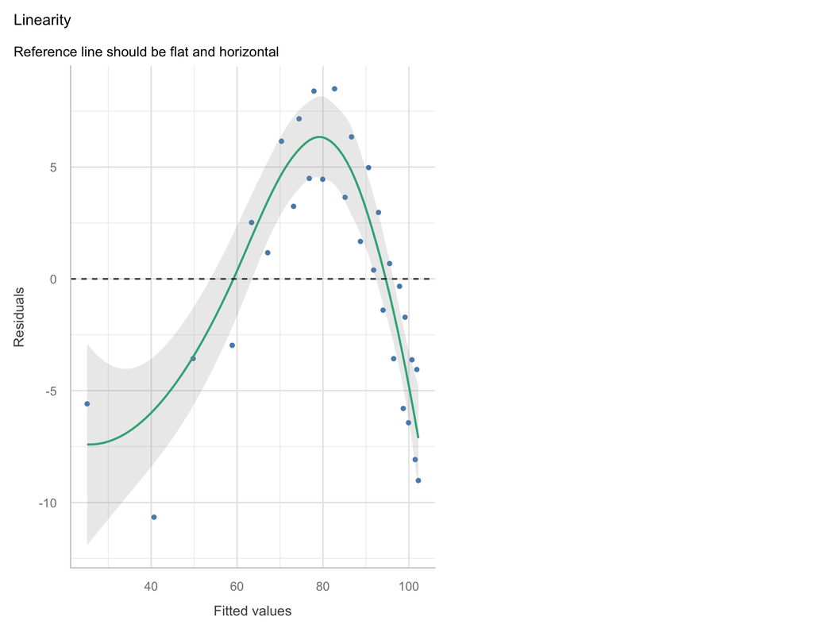

```r
shape_bad_log_model <- lm(quiz_score ~ log(study_hours), data = shape_bad)
check_model(shape_bad_log_model, check = "linearity")
```

### Multiple predictors: hospital recovery time

Predict **recovery time after knee surgery** (days) from three continuous predictors:

- **Age** (years)
- **Injury severity** (clinician score, 1 to 10)
- **Baseline mobility** (pre-injury function score, 0 to 100)

There is no scatterplot that shows all three predictors and the outcome at once. You could plot recovery against each predictor separately, but each plot ignores the others.

```r
mlr_shape <- data.frame(
  age = c(81, 46, 29, 26, 37, 70, 42, 80, 32, 50, 32, 36, 68, 28, 49, 27, 56, 23, 81, 41, 60, 40, 82, 76, 81, 26, 60, 51, 80, 44, 63, 38, 33, 33, 45, 73, 52, 69, 72, 49, 70, 45, 68, 48, 76, 41, 27, 71, 76, 80, 56, 65, 68, 60, 65, 45, 32, 33, 45, 38),
  severity = c(2.7, 5.5, 7.9, 7.2, 5.9, 6.9, 5.2, 5.3, 4, 4.8, 3.6, 6.4, 8.6, 6.6, 2.2, 6.1, 5, 4.9, 6.6, 9.4, 9, 8.9, 3.2, 7.7, 4.5, 1.7, 1.9, 7.9, 4.1, 4.8, 4.1, 1.1, 9.2, 2.6, 7.5, 6.1, 5.9, 4.2, 8.4, 2.7, 4.6, 5.4, 5.5, 4.5, 6.8, 4.1, 9.6, 1.4, 7.9, 2.8, 7.2, 4.6, 1.5, 7.6, 6.6, 6.7, 6.1, 8.1, 2.7, 8.5),
  mobility = c(57, 53, 60, 33, 72, 41, 76, 28, 65, 24, 84, 77, 77, 55, 85, 68, 87, 80, 76, 79, 68, 56, 29, 60, 37, 73, 30, 89, 19, 92, 22, 87, 30, 31, 38, 79, 53, 77, 94, 80, 66, 83, 55, 68, 56, 57, 43, 80, 32, 49, 45, 78, 44, 74, 45, 72, 18, 55, 73, 93),
  recovery_days = c(8.7, 10.6, 15.1, 14.9, 11.6, 14.5, 10.7, 13.3, 7.2, 13.4, 6.7, 12.1, 17, 11.4, 4.6, 9.7, 10.4, 9.2, 14.5, 17.6, 17.5, 17.5, 11.1, 16.6, 10.7, 4.1, 6.2, 15.5, 15.6, 8.9, 12.1, 3.1, 20.1, 7, 15.9, 13.8, 12.5, 9, 15.1, 6.2, 9.6, 10.7, 12.7, 9.3, 15.5, 7.7, 18.8, 4.7, 18.5, 8.6, 13.7, 8.8, 5.2, 15, 14.5, 12.6, 16.1, 15.7, 5.7, 14.3)
)
```

Recovery versus injury severity alone looks roughly linear, so a single scatterplot does not raise any alarms.

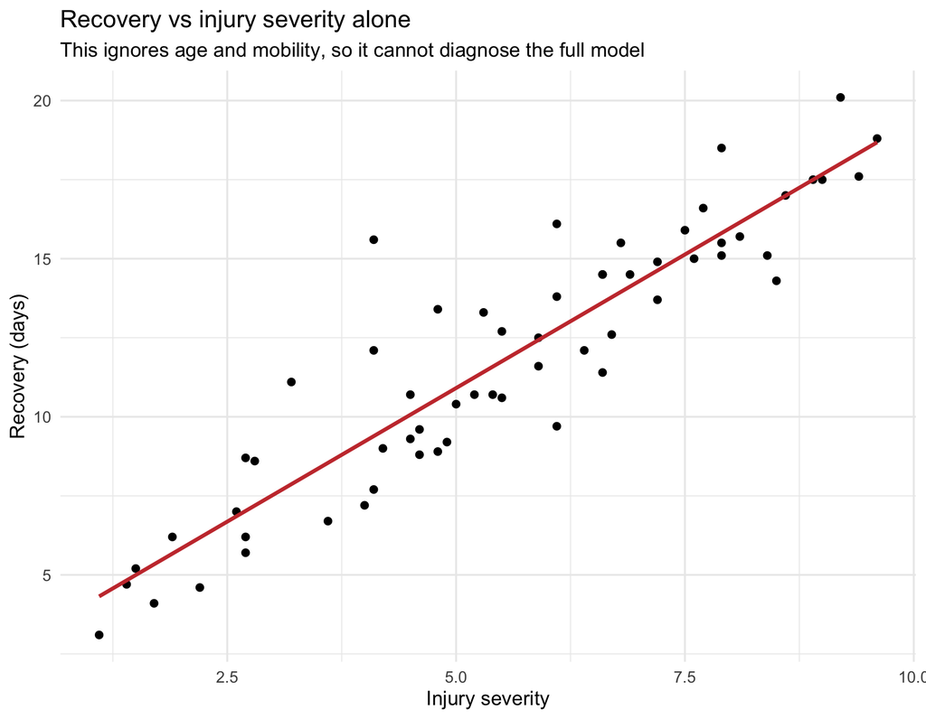

```r
ggplot(mlr_shape, aes(severity, recovery_days)) +
  geom_point(size = 2) +
  geom_smooth(method = "lm", se = FALSE, colour = "#C83B3B") +
  labs(
    title = "Recovery vs injury severity alone",
    subtitle = "This ignores age and mobility, so it cannot diagnose the full model",
    x = "Injury severity",
    y = "Recovery (days)"
  ) +
  theme_minimal(base_size = 14)
```

Fit the full multiple regression model and read the **Linearity** panel.

```r
mlr_shape_model <- lm(recovery_days ~ age + severity + mobility, data = mlr_shape)
summary(mlr_shape_model)
```

```
##
## Call:
## lm(formula = recovery_days ~ age + severity + mobility, data = mlr_shape)
##
## Residuals:
##      Min       1Q   Median       3Q      Max
## -1.88906 -0.41058  0.09067  0.52406  3.11726
##
## Coefficients:
##              Estimate Std. Error t value Pr(>|t|)
## (Intercept)  3.225065   0.650789   4.956 7.02e-06 ***
## age          0.039067   0.006774   5.767 3.63e-07 ***
## severity     1.731785   0.053602  32.308  < 2e-16 ***
## mobility    -0.050946   0.005711  -8.921 2.42e-12 ***
## ---
## Signif. codes:  0 '***' 0.001 '**' 0.01 '*' 0.05 '.' 0.1 ' ' 1
##
## Residual standard error: 0.9259 on 56 degrees of freedom
## Multiple R-squared:  0.9534, Adjusted R-squared:  0.9509
## F-statistic: 382.1 on 3 and 56 DF,  p-value: < 2.2e-16
```

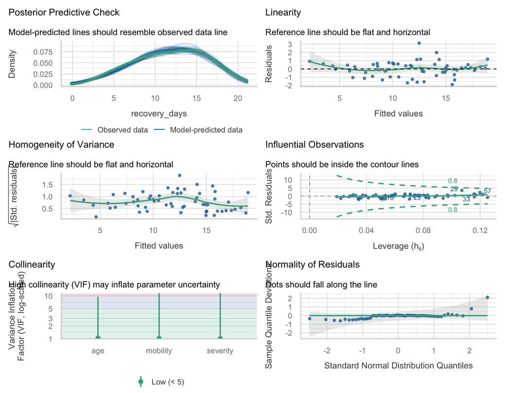

```r
check_model(mlr_shape_model)
```

### Practice

Fertilizer applied (kg per plot) vs. crop yield (kg).

Fit the model, look at the scatter plot, then read the **Linearity** panel of the diagnostics. Does the relationship satisfy the linearity assumption?

```r
practice_1 <- data.frame(
  fertilizer = c(2, 4, 6, 8, 10, 12, 14, 16, 18, 20, 22, 24, 26, 28, 30, 32, 34, 36, 38, 40, 5, 11, 17, 23, 29, 35, 7, 15, 25, 33),
  yield      = c(13.9, 20.2, 32.7, 35, 42.6, 43.2, 50.9, 50.5, 56.6, 53.3, 58.1, 54.7, 60.6, 57.7, 62.3, 58.2, 61.6, 58.4, 63.1, 59.8, 26.9, 44.7, 51.1, 59.2, 57.5, 62.2, 32.5, 52.3, 56.6, 61.4)
)
```

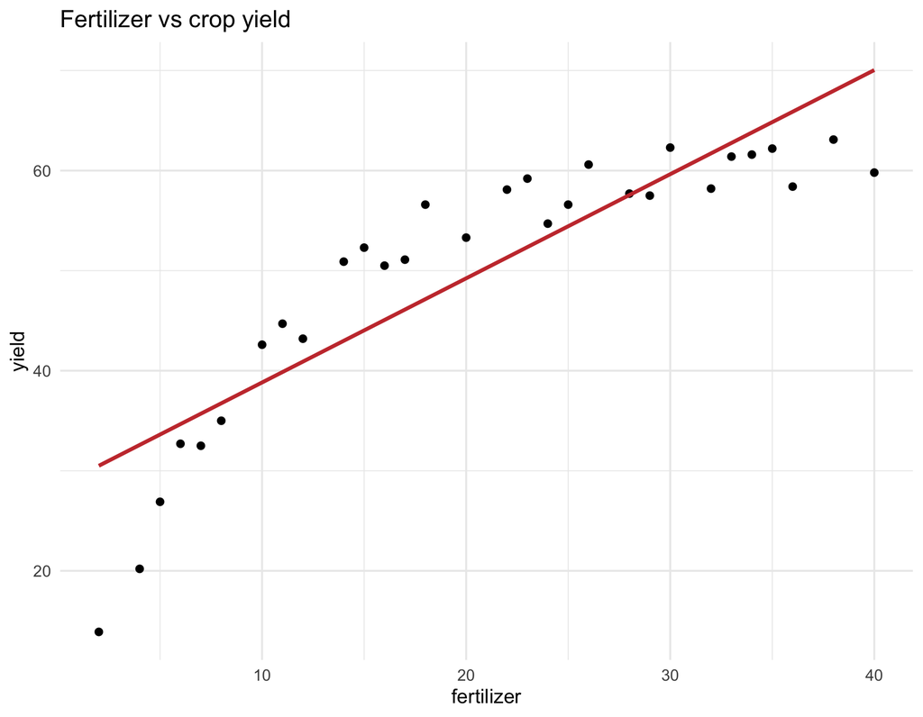

```r
ggplot(practice_1, aes(fertilizer, yield)) +
  geom_point(size = 2) +
  geom_smooth(method = "lm", se = FALSE, colour = "#C83B3B") +
  labs(title = "Fertilizer vs crop yield") +
  theme_minimal(base_size = 14)
```

```r
practice_1_model <- lm(yield ~ fertilizer, data = practice_1)
summary(practice_1_model)
```

```
##
## Call:
## lm(formula = yield ~ fertilizer, data = practice_1)
##
## Residuals:
##      Min       1Q   Median       3Q      Max
## -16.6011  -3.0640   0.7232   4.9501   9.4484
##
## Coefficients:
##             Estimate Std. Error t value Pr(>|t|)
## (Intercept)  28.4198     2.4972  11.381 5.14e-12 ***
## fertilizer    1.0407     0.1065   9.773 1.60e-10 ***
## ---
## Signif. codes:  0 '***' 0.001 '**' 0.01 '*' 0.05 '.' 0.1 ' ' 1
##
## Residual standard error: 6.464 on 28 degrees of freedom
## Multiple R-squared:  0.7733, Adjusted R-squared:  0.7652
## F-statistic: 95.51 on 1 and 28 DF,  p-value: 1.595e-10
```

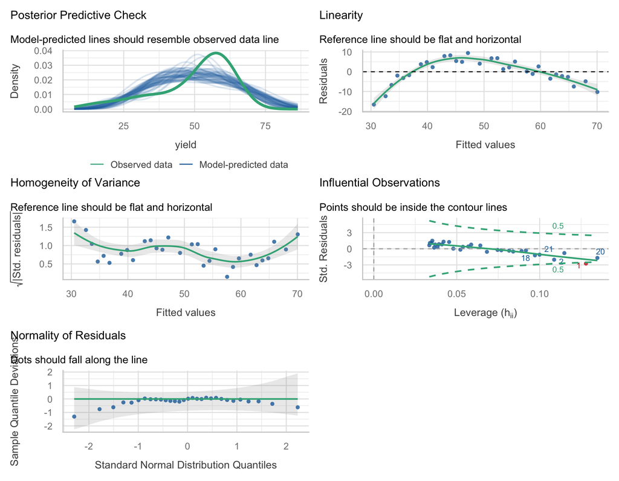

```r
check_model(practice_1_model)
```

**Your answer here:**

## H: Homoscedasticity (Equal Variance)

The question here is: does the *spread* of the residuals stay constant across the range?

For this, we read the **Homogeneity of variance** panel (scale-location).

A flat green line means even spread. If the line slopes upward, then the spread of the residuals increases with the fitted value.

### Exercise duration and calories (homoscedastic variance)

Exercise duration vs. calories burned.

The spread looks the same for short and long workouts.

```r
hom_good <- data.frame(
  exercise_min = c(15, 20, 22, 25, 28, 30, 33, 35, 37, 40, 42, 45, 48, 50, 52, 55, 58, 60, 63, 65, 18, 27, 34, 39, 44, 49, 54, 57, 62, 36),
  calories     = c(149, 158, 193, 185, 218, 210, 250, 246, 281, 271, 299, 298, 338, 334, 366, 360, 393, 386, 426, 419, 167, 197, 255, 261, 311, 323, 377, 374, 419, 247)
)
```

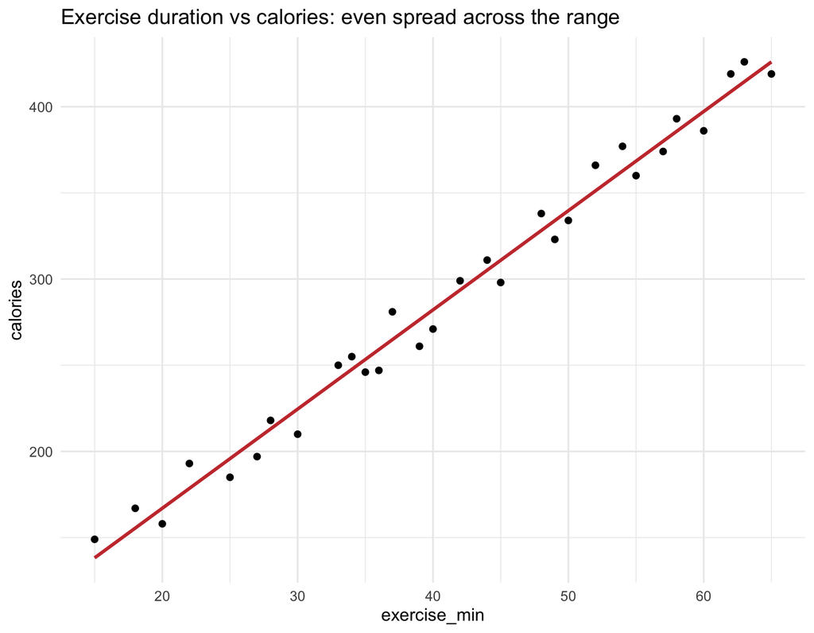

```r
ggplot(hom_good, aes(exercise_min, calories)) +
  geom_point(size = 2) +
  geom_smooth(method = "lm", se = FALSE, colour = "#C83B3B") +
  labs(title = "Exercise duration vs calories: even spread across the range") +
  theme_minimal(base_size = 14)
```

```r
hom_good_model <- lm(calories ~ exercise_min, data = hom_good)
summary(hom_good_model)
```

```
##
## Call:
## lm(formula = calories ~ exercise_min, data = hom_good)
##
## Residuals:
##      Min       1Q   Median       3Q      Max
## -15.3638 -10.6766  -0.3638  10.1714  16.1454
##
## Coefficients:
##              Estimate Std. Error t value Pr(>|t|)
## (Intercept)    51.934      6.218   8.352 4.37e-09 ***
## exercise_min    5.755      0.142  40.535  < 2e-16 ***
## ---
## Signif. codes:  0 '***' 0.001 '**' 0.01 '*' 0.05 '.' 0.1 ' ' 1
##
## Residual standard error: 11.04 on 28 degrees of freedom
## Multiple R-squared:  0.9832, Adjusted R-squared:  0.9826
## F-statistic:  1643 on 1 and 28 DF,  p-value: < 2.2e-16
```

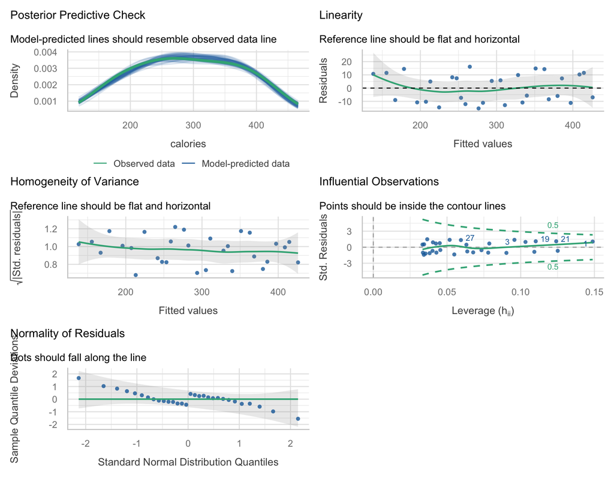

```r
check_model(hom_good_model)
```

Here the *Homogeneity* green line is roughly flat.

This means that the spread of the residuals is roughly constant across the range of the predictor.

### Income and medical spending (heteroscedasticity)

Household income vs. out-of-pocket medical spending.

Wealthier households have far more discretionary spending, so the spread gets larger at the high end, giving you a fan-shaped scatter.

```r
hom_bad <- data.frame(
  income_k      = c(20, 25, 28, 32, 35, 38, 42, 45, 48, 52, 55, 58, 62, 65, 68, 72, 75, 80, 85, 90, 95, 100, 110, 120, 22, 40, 56, 70, 88, 105),
  medical_spend = c(464, 475, 573, 622, 495, 786, 593, 943, 744, 828, 682, 1052, 1000, 919, 842, 1294, 851, 1526, 961, 994, 1573, 1052, 2024, 2030, 555, 560, 1152, 718, 1729, 855)
)
```

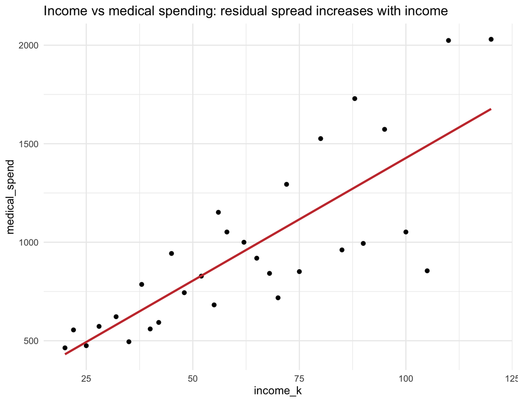

```r
ggplot(hom_bad, aes(income_k, medical_spend)) +
  geom_point(size = 2) +
  geom_smooth(method = "lm", se = FALSE, colour = "#C83B3B") +
  labs(title = "Income vs medical spending: residual spread increases with income") +
  theme_minimal(base_size = 14)
```

```r
hom_bad_model <- lm(medical_spend ~ income_k, data = hom_bad)
summary(hom_bad_model)
```

```
##
## Call:
## lm(formula = medical_spend ~ income_k, data = hom_bad)
##
## Residuals:
##     Min      1Q  Median      3Q     Max
## -634.77 -169.68   15.39  187.11  471.97
##
## Coefficients:
##             Estimate Std. Error t value Pr(>|t|)
## (Intercept)  182.350    120.622   1.512    0.142
## income_k      12.452      1.764   7.060 1.11e-07 ***
## ---
## Signif. codes:  0 '***' 0.001 '**' 0.01 '*' 0.05 '.' 0.1 ' ' 1
##
## Residual standard error: 263.9 on 28 degrees of freedom
## Multiple R-squared:  0.6403, Adjusted R-squared:  0.6275
## F-statistic: 49.85 on 1 and 28 DF,  p-value: 1.113e-07
```

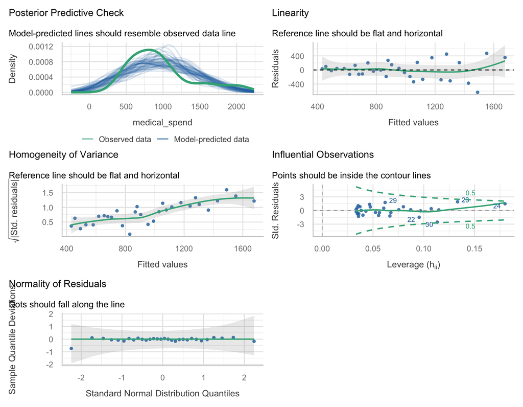

```r
check_model(hom_bad_model)
```

The *Homogeneity of variance* green line slopes upward, indicating that the spread of the residuals increases with the fitted value.

This is a sign of heteroscedasticity.

Because the plot already suggests a problem, we can run the formal test to confirm:

```r
check_heteroscedasticity(hom_bad_model)
```

[output not shown]

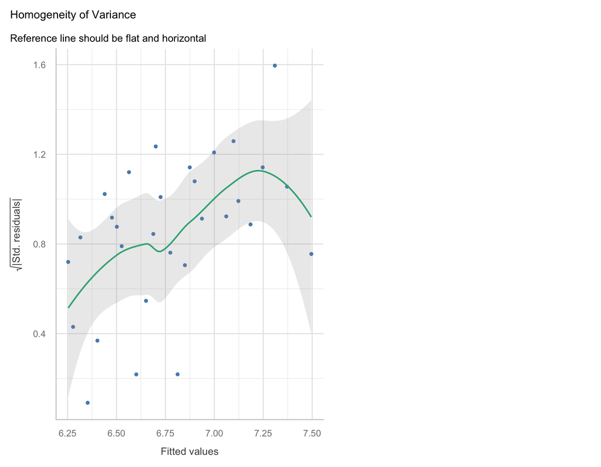

```r
hom_bad_log_model <- lm(log(medical_spend) ~ income_k, data = hom_bad)
check_model(hom_bad_log_model, check = "homogeneity")
```

Other options include using robust (heteroscedasticity-consistent) standard errors, but the log transformation is the most common first step when the outcome is a positive, right-skewed quantity like spending.

### Practice

Daily patient volume at a clinic vs. patient waiting time (minutes).

Fit the model, look at the scatter plot, then read the **Homogeneity of variance** panel. Does the relationship satisfy the equal-variance assumption?

```r
practice_2 <- data.frame(
  patient_volume = c(10, 14, 18, 22, 26, 30, 34, 38, 42, 46, 50, 54, 58, 62, 66, 70, 74, 78, 82, 90, 12, 28, 44, 60, 76, 86, 16, 36, 56, 72),
  wait_time      = c(23, 31, 28, 41, 33, 47, 35, 63, 41, 71, 40, 78, 93, 48, 42, 116, 52, 131, 52, 39, 28, 31, 74, 39, 131, 46, 33, 33, 96, 38)
)
```

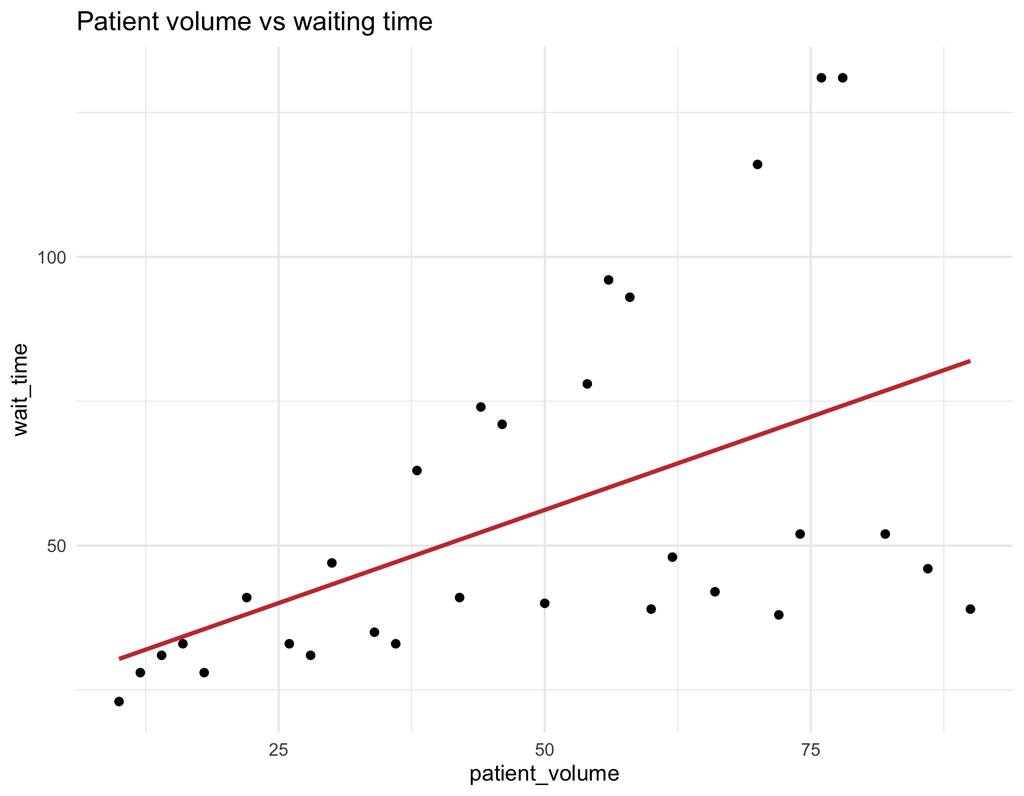

```r
ggplot(practice_2, aes(patient_volume, wait_time)) +
  geom_point(size = 2) +
  geom_smooth(method = "lm", se = FALSE, colour = "#C83B3B") +
  labs(title = "Patient volume vs waiting time") +
  theme_minimal(base_size = 14)
```

```r
practice_2_model <- lm(wait_time ~ patient_volume, data = practice_2)
summary(practice_2_model)
```

```
##
## Call:
## lm(formula = wait_time ~ patient_volume, data = practice_2)
##
## Residuals:
##     Min      1Q  Median      3Q     Max
## -42.979 -16.110  -7.452  16.695  58.052
##
## Coefficients:
##                Estimate Std. Error t value Pr(>|t|)
## (Intercept)     23.9204    11.0507   2.165  0.03910 *
## patient_volume   0.6451     0.2053   3.142  0.00394 **
## ---
## Signif. codes:  0 '***' 0.001 '**' 0.01 '*' 0.05 '.' 0.1 ' ' 1
##
## Residual standard error: 26.65 on 28 degrees of freedom
## Multiple R-squared:  0.2607, Adjusted R-squared:  0.2343
## F-statistic: 9.875 on 1 and 28 DF,  p-value: 0.003937
```

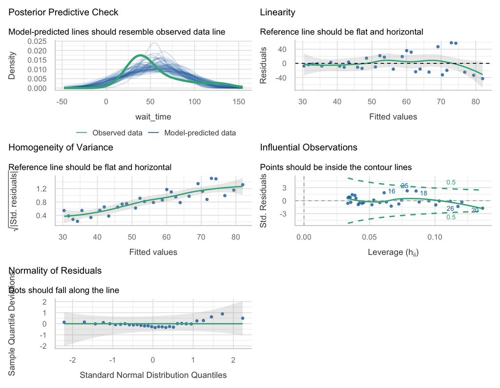

```r
check_model(practice_2_model)
```

**Your answer here:**

## I: Influential Points

The question here is: is any single observation pulling the line around?

For this, we read the **Influential observations** panel (residuals vs leverage).

Points that sit *outside the dashed contour* combine an unusual x-value (leverage) with a large residual (off the line).

### BMI and cholesterol without outliers (no influential points)

BMI vs. cholesterol from a routine screening, with no data-entry errors.

```r
inf_bad <- data.frame(
  bmi         = c(19, 20, 21, 22, 23, 23.5, 24, 24.5, 25, 25.5, 26, 26.5, 27, 27.5, 28, 28.5, 29, 29.5, 30, 30.5, 31, 20.5, 23, 25.5, 27, 29, 22, 24.5, 26.5, 28.5, 42),
  cholesterol = c(216, 204, 229, 211, 228, 214, 236, 226, 249, 225, 243, 225, 252, 238, 258, 240, 265, 243, 261, 245, 276, 220, 214, 241, 234, 265, 213, 242, 229, 256, 130)
)
inf_good <- inf_bad %>% filter(bmi != 42)
```

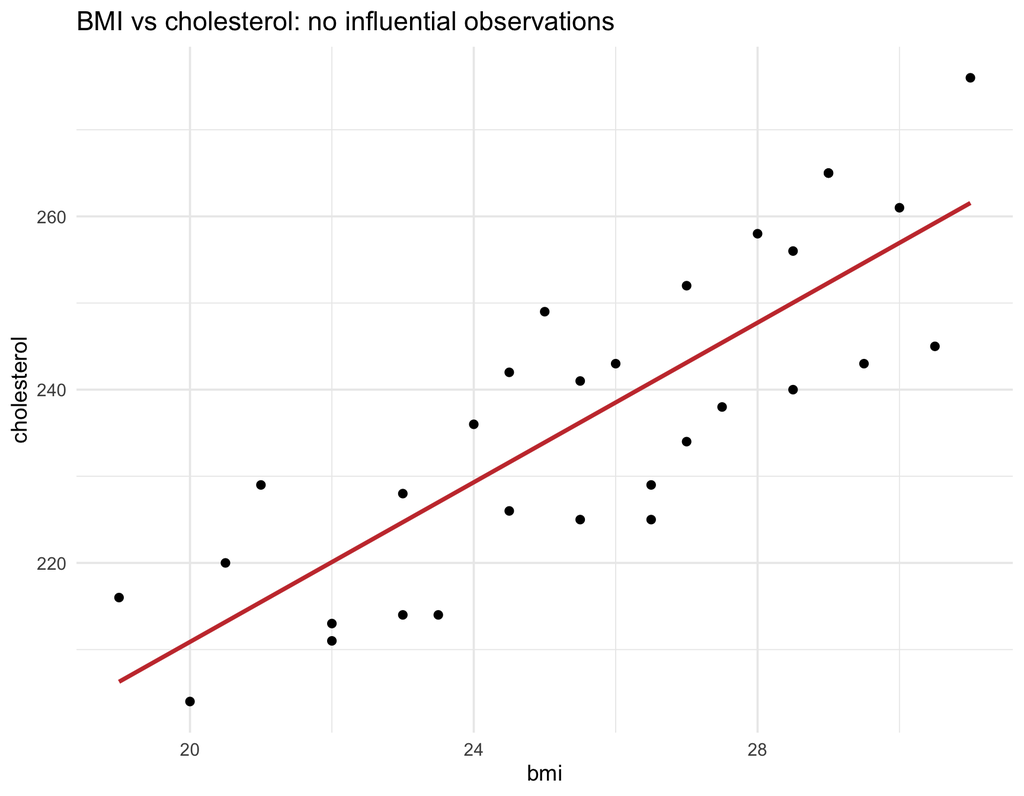

```r
ggplot(inf_good, aes(bmi, cholesterol)) +
  geom_point(size = 2) +
  geom_smooth(method = "lm", se = FALSE, colour = "#C83B3B") +
  labs(title = "BMI vs cholesterol: no influential observations") +
  theme_minimal(base_size = 14)
```

```r
inf_good_model <- lm(cholesterol ~ bmi, data = inf_good)
summary(inf_good_model)
```

```
##
## Call:
## lm(formula = cholesterol ~ bmi, data = inf_good)
##
## Residuals:
##     Min      1Q  Median      3Q     Max
## -15.822  -9.807   3.678   9.511  15.087
##
## Coefficients:
##             Estimate Std. Error t value Pr(>|t|)
## (Intercept)  118.761     15.342   7.741 1.97e-08 ***
## bmi            4.606      0.595   7.742 1.96e-08 ***
## ---
## Signif. codes:  0 '***' 0.001 '**' 0.01 '*' 0.05 '.' 0.1 ' ' 1
##
## Residual standard error: 10.54 on 28 degrees of freedom
## Multiple R-squared:  0.6816, Adjusted R-squared:  0.6702
## F-statistic: 59.94 on 1 and 28 DF,  p-value: 1.963e-08
```

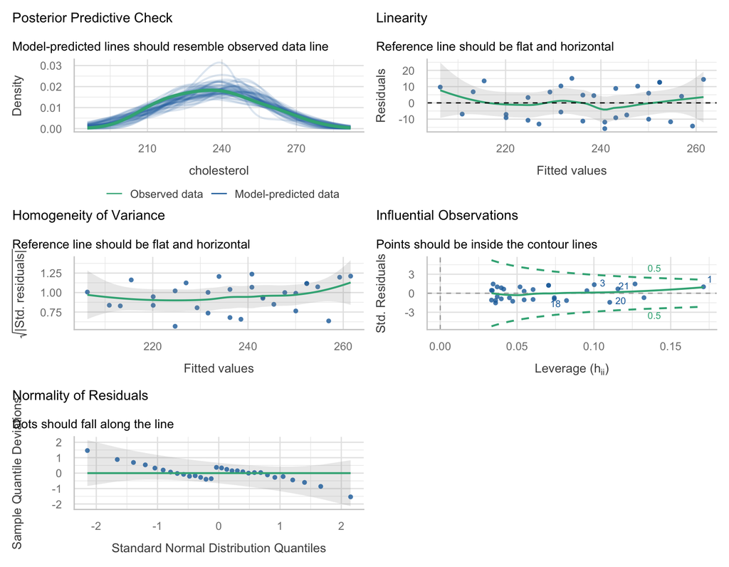

```r
check_model(inf_good_model)
```

Every point stays well inside the dashed contour in the *Influential observations* panel.

No single observation stands out as influential.

### BMI and cholesterol with data-entry error (influential point)

The same screening, but with a likely data-entry error: BMI = 42 paired with cholesterol = 130, which is unusually low for that BMI.

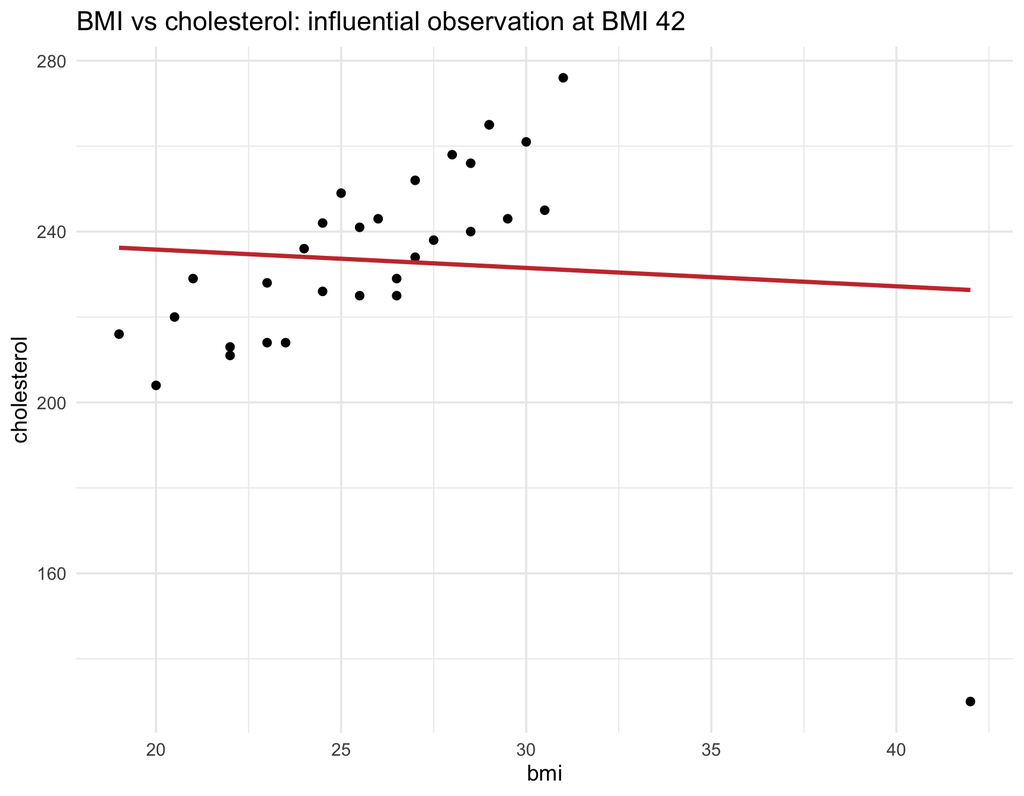

```r
ggplot(inf_bad, aes(bmi, cholesterol)) +
  geom_point(size = 2) +
  geom_smooth(method = "lm", se = FALSE, colour = "#C83B3B") +
  labs(title = "BMI vs cholesterol: influential observation at BMI 42") +
  theme_minimal(base_size = 14)
```

To diagnose, we look at the *Influential observations* panel in the check_model() output.

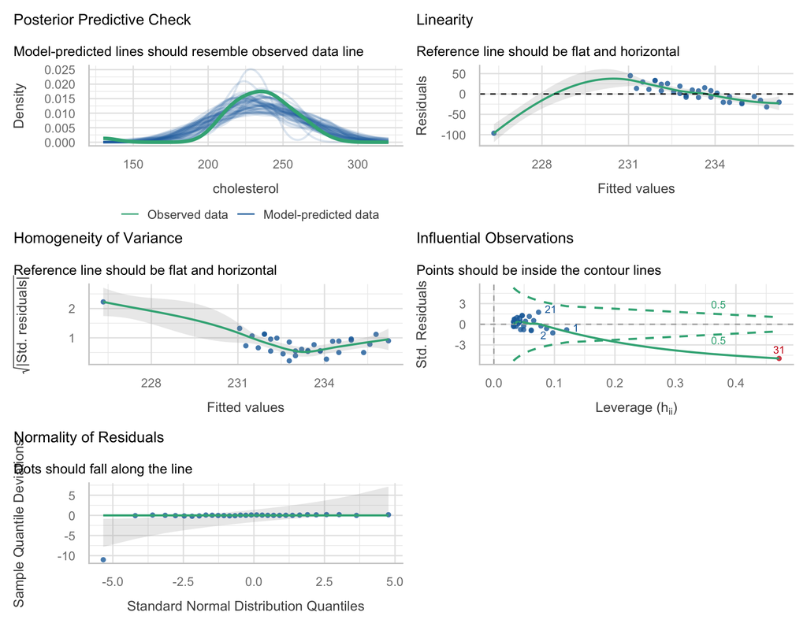

```r
inf_bad_model  <- lm(cholesterol ~ bmi, data = inf_bad)
check_model(inf_bad_model)
```

In the *Influential observations* panel, one point lies far to the right, outside the dashed contour.

It has both high leverage (BMI 42 is well above the rest of the data) and a large residual (far from the fitted line).

Removing it would noticeably change the fit.

Because the plot already flags a point, we can run the formal check to confirm which observation it is:

```r
check_outliers(inf_bad_model)
```

```
## 1 outlier detected: case 31.
## - Based on the following method and threshold: cook (0.71).
## - For variable: (Whole model).
```

The function names the row so you can go back to the raw data and inspect it. As before, use this to follow up on a point you have already seen in the plot, not as a routine screen.

**One way to fix it:** investigate the observation before doing anything else. If it is a data-entry error, correct it or remove it and say so in your report. If the value is genuine, the usual approach is to report the model both with and without the point, so readers can see how much it changes the results. Do not silently delete real observations just because they are inconvenient.

### Practice

Blood lead level (µg/dL) vs. reaction time on a cognitive test (milliseconds).

Fit the model, look at the scatter plot, then read the **Influential observations** panel. Is any single observation pulling the line around?

```r
practice_3 <- data.frame(
  lead_level    = c(2, 4, 6, 8, 10, 12, 14, 16, 18, 20, 22, 24, 26, 28, 30, 3, 9, 15, 21, 27, 5, 11, 17, 23, 29, 7, 13, 19, 25, 45),
  reaction_time = c(208, 208, 219, 217, 227, 226, 238, 239, 250, 247, 257, 256, 268, 268, 279, 205, 225, 234, 256, 267, 218, 225, 245, 254, 276, 216, 237, 245, 265, 215)
)
```

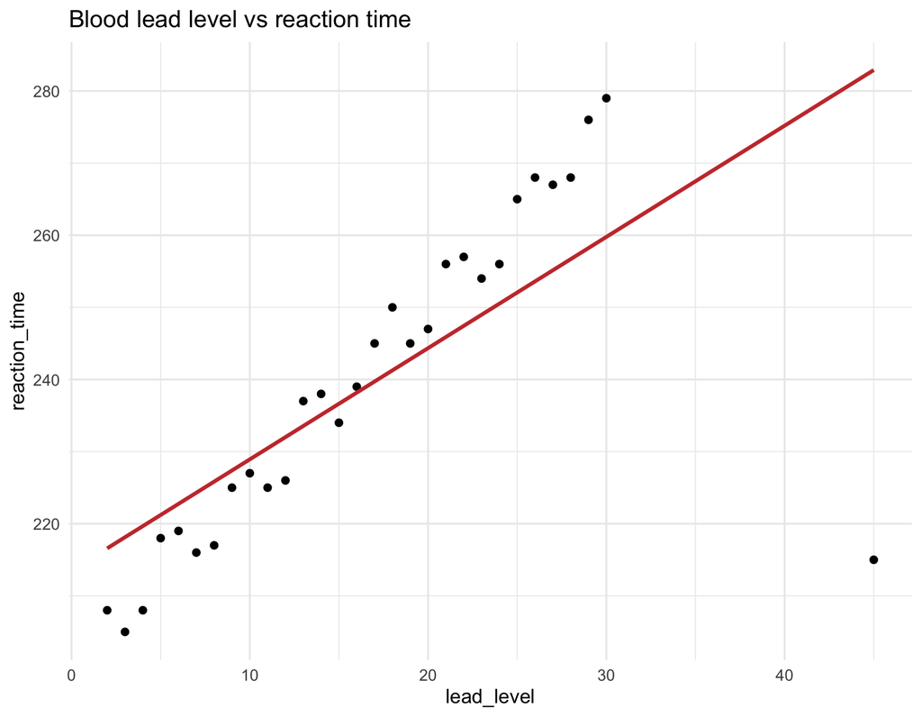

```r
ggplot(practice_3, aes(lead_level, reaction_time)) +
  geom_point(size = 2) +
  geom_smooth(method = "lm", se = FALSE, colour = "#C83B3B") +
  labs(title = "Blood lead level vs reaction time") +
  theme_minimal(base_size = 14)
```

```r
practice_3_model <- lm(reaction_time ~ lead_level, data = practice_3)
summary(practice_3_model)
```

```
##
## Call:
## lm(formula = reaction_time ~ lead_level, data = practice_3)
##
## Residuals:
##     Min      1Q  Median      3Q     Max
## -67.902  -5.037   2.426   9.363  19.232
##
## Coefficients:
##             Estimate Std. Error t value Pr(>|t|)
## (Intercept) 213.4992     5.7850  36.906  < 2e-16 ***
## lead_level    1.5423     0.2957   5.215 1.54e-05 ***
## ---
## Signif. codes:  0 '***' 0.001 '**' 0.01 '*' 0.05 '.' 0.1 ' ' 1
##
## Residual standard error: 15.77 on 28 degrees of freedom
## Multiple R-squared:  0.4927, Adjusted R-squared:  0.4746
## F-statistic:  27.2 on 1 and 28 DF,  p-value: 1.541e-05
```

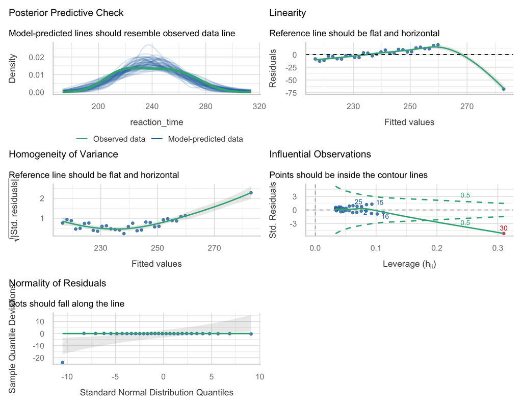

```r
check_model(practice_3_model)
```

**Your answer here:**

## N: Normality of Residuals

**The question:** are the prediction errors roughly bell-shaped?

We read the **Normality of residuals** panel (the Q-Q plot).

Points close to the reference line are good; points diverging at the ends indicate skew or heavy tails.

### Height and lung capacity (normal residuals)

Height vs. lung capacity.

Errors scatter symmetrically around the line.

```r
norm_good <- data.frame(
  height_cm     = c(154.7, 155.6, 155.8, 156.3, 157.6, 158, 158.6, 159.4, 159.6, 160.6, 160.4, 161, 162, 162.4, 163.3, 164.2, 164.8, 164.7, 165.8, 166.4, 166.6, 167.1, 167.8, 169, 168.9, 169.7, 169.9, 171.4, 171.4, 171.7, 173, 173.5, 173.7, 174.7, 174.9, 175.4, 175.9, 176.8, 177.4, 177.8, 179.1, 179, 180.1, 180.5, 181.2, 182.2, 181.9, 182.9, 183.8, 184, 185.1, 185.8, 185.8, 185.9, 187.1, 188, 188.4, 188.3, 189, 190.1),
  lung_capacity = c(3.54, 3.88, 3.61, 3.92, 3.98, 3.75, 3.43, 3.89, 3.59, 3.67, 3.47, 3.7, 3.98, 3.41, 3.78, 4.08, 3.85, 3.91, 3.77, 3.93, 3.82, 3.72, 3.99, 4.2, 4.27, 4.1, 3.78, 4.13, 4.15, 4.4, 4.08, 4.16, 4.2, 4.21, 4.54, 4.67, 4.55, 4.54, 4.54, 4.34, 4.62, 4.53, 4.49, 4.57, 4.67, 4.41, 4.25, 4.92, 4.64, 4.8, 4.63, 4.8, 5.03, 4.88, 4.94, 4.92, 5.01, 4.93, 4.8, 5.17)
)
```

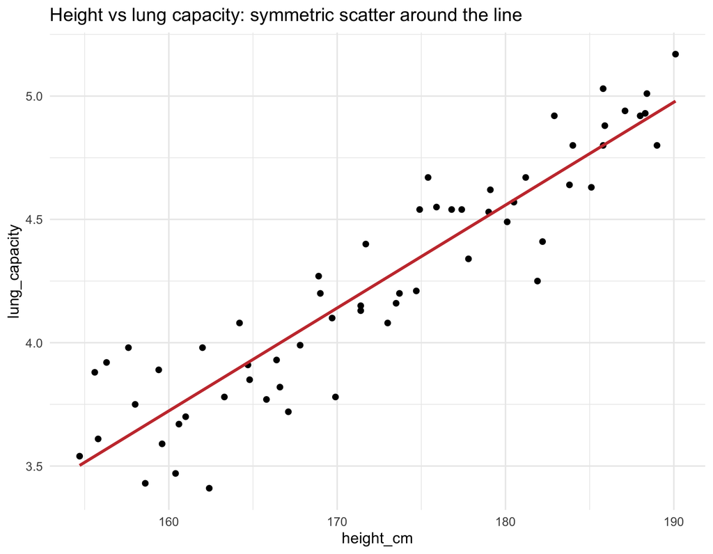

```r
ggplot(norm_good, aes(height_cm, lung_capacity)) +
  geom_point(size = 2) +
  geom_smooth(method = "lm", se = FALSE, colour = "#C83B3B") +
  labs(title = "Height vs lung capacity: symmetric scatter around the line") +
  theme_minimal(base_size = 14)
```

```r
norm_good_model <- lm(lung_capacity ~ height_cm, data = norm_good)
summary(norm_good_model)
```

```
##
## Call:
## lm(formula = lung_capacity ~ height_cm, data = norm_good)
##
## Residuals:
##      Min       1Q   Median       3Q      Max
## -0.41372 -0.11923 -0.00446  0.11126  0.35655
##
## Coefficients:
##              Estimate Std. Error t value Pr(>|t|)
## (Intercept) -2.951996   0.392626  -7.519 3.94e-10 ***
## height_cm    0.041722   0.002273  18.356  < 2e-16 ***
## ---
## Signif. codes:  0 '***' 0.001 '**' 0.01 '*' 0.05 '.' 0.1 ' ' 1
##
## Residual standard error: 0.1817 on 58 degrees of freedom
## Multiple R-squared:  0.8531, Adjusted R-squared:  0.8506
## F-statistic:   337 on 1 and 58 DF,  p-value: < 2.2e-16
```

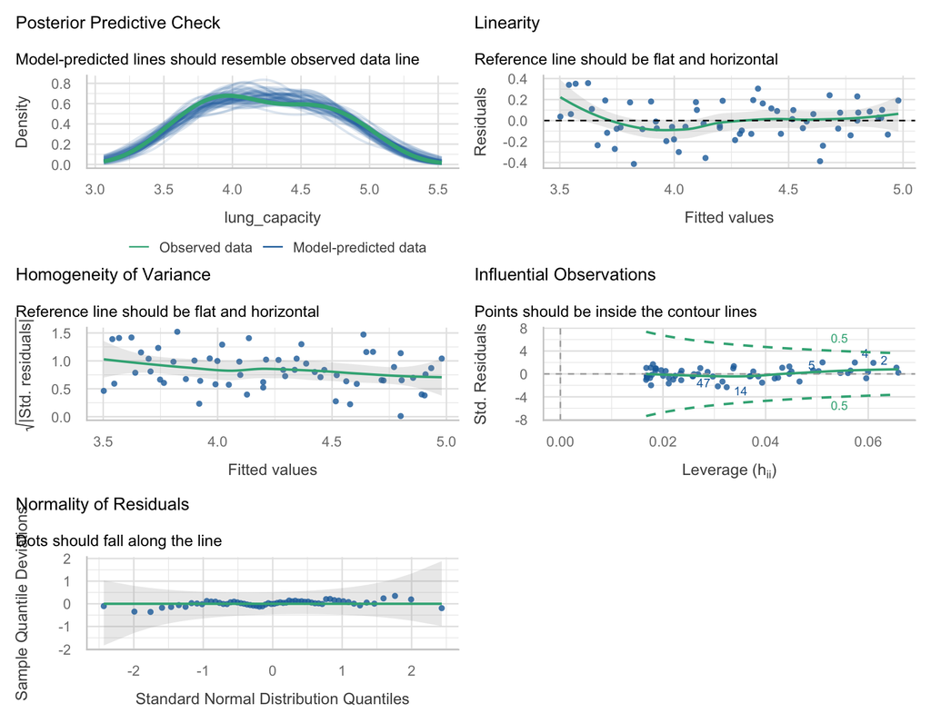

```r
check_model(norm_good_model)
```

The Q-Q points sit on (or very near) the diagonal across the whole range, and inside the shaded band.

That is what approximately normal residuals look like.

### Poverty rate and ER visits (non-normal residuals)

Neighbourhood poverty rate vs. ER visits per 1,000.

Most neighbourhoods follow the trend, but several have unusually high visit rates, producing strongly right-skewed residuals.

```r
norm_bad <- data.frame(
  poverty_rate = c(5, 7, 8, 10, 12, 13, 15, 16, 18, 19, 20, 22, 23, 25, 27, 28, 30, 32, 34, 35, 37, 38, 40, 42, 6, 14, 21, 29, 36, 41),
  er_visits    = c(113, 105, 107, 112, 213, 122, 119, 124, 205, 154, 150, 159, 243, 155, 176, 178, 280, 191, 207, 199, 280, 195, 222, 220, 99, 129, 219, 181, 211, 296)
)
```

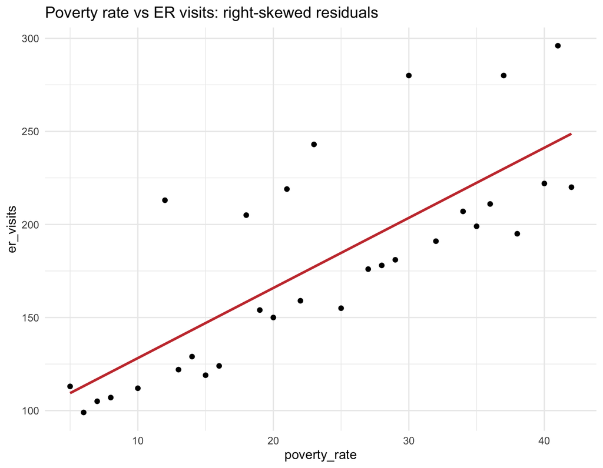

```r
ggplot(norm_bad, aes(poverty_rate, er_visits)) +
  geom_point(size = 2) +
  geom_smooth(method = "lm", se = FALSE, colour = "#C83B3B") +
  labs(title = "Poverty rate vs ER visits: right-skewed residuals") +
  theme_minimal(base_size = 14)
```

```r
norm_bad_model <- lm(er_visits ~ poverty_rate, data = norm_bad)
summary(norm_bad_model)
```

```
##
## Call:
## lm(formula = er_visits ~ poverty_rate, data = norm_bad)
##
## Residuals:
##     Min      1Q  Median      3Q     Max
## -38.665 -19.090 -14.767   0.696  77.263
##
## Coefficients:
##              Estimate Std. Error t value Pr(>|t|)
## (Intercept)   90.5395    14.9720   6.047 1.61e-06 ***
## poverty_rate   3.7665     0.5764   6.534 4.40e-07 ***
## ---
## Signif. codes:  0 '***' 0.001 '**' 0.01 '*' 0.05 '.' 0.1 ' ' 1
##
## Residual standard error: 35.38 on 28 degrees of freedom
## Multiple R-squared:  0.604,  Adjusted R-squared:  0.5898
## F-statistic:  42.7 on 1 and 28 DF,  p-value: 4.399e-07
```

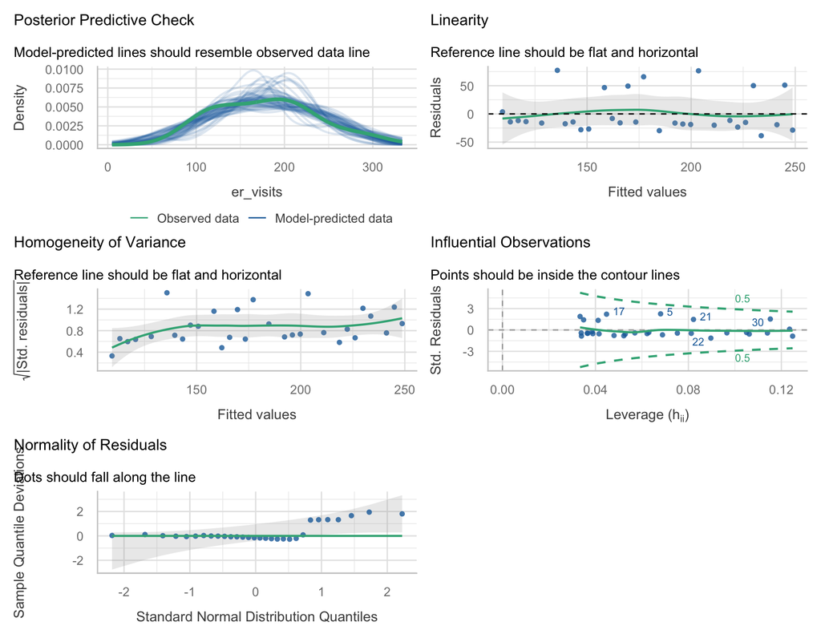

```r
check_model(norm_bad_model)
```

In the *Normality* Q-Q panel, the points bend away from the reference line at the upper end.

That is the long right tail of the skewed residuals.

Because the Q-Q plot already shows a clear bend, we can run the formal test to confirm:

```r
check_normality(norm_bad_model)
```

[output not shown]

Again, this test belongs after a visual signal. On a model whose Q-Q plot looks fine, a significant result from `check_normality()` usually reflects a minor departure that does not matter.

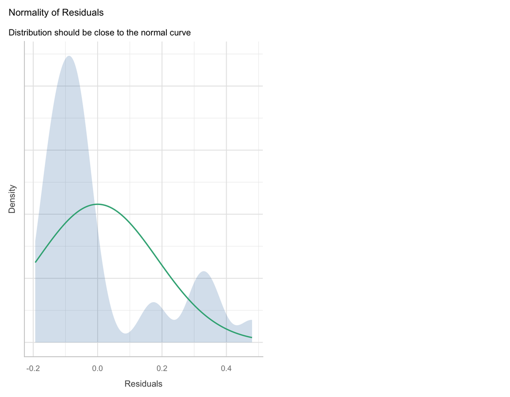

```r
norm_bad_log_model <- lm(log(er_visits) ~ poverty_rate, data = norm_bad)
check_model(norm_bad_log_model, check = "normality")
```

Other options exist (for example, a generalized linear model suited to the outcome type), but the log transformation is the most common first step.

### Practice

Gestational age at delivery (weeks) vs. birth weight (grams).

Fit the model, look at the scatter plot, then read the **Normality of residuals** panel. Are the residuals roughly bell-shaped?

```r
practice_4 <- data.frame(
  gestational_age = c(35, 35.5, 36, 36.5, 37, 37.5, 38, 38.5, 39, 39.5, 40, 40.5, 41, 41.5, 42, 35.2, 36.8, 37.6, 38.4, 39.2, 40.2, 41.2, 36.2, 37.2, 38.2, 39.6, 40.6, 37.8, 39.8, 41.6),
  birth_weight    = c(2730, 2506, 2639, 2903, 2674, 3008, 3016, 3212, 3240, 3326, 3469, 3667, 3713, 3836, 3789, 2633, 2775, 2915, 3121, 3525, 3463, 3791, 2765, 2975, 3157, 3531, 3676, 3009, 3538, 3816)
)
```

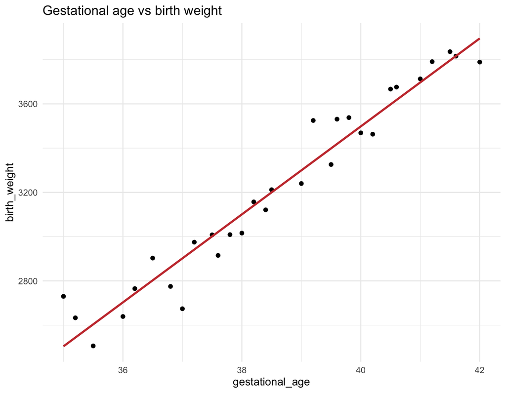

```r
ggplot(practice_4, aes(gestational_age, birth_weight)) +
  geom_point(size = 2) +
  geom_smooth(method = "lm", se = FALSE, colour = "#C83B3B") +
  labs(title = "Gestational age vs birth weight") +
  theme_minimal(base_size = 14)
```

```r
practice_4_model <- lm(birth_weight ~ gestational_age, data = practice_4)
summary(practice_4_model)
```

```
##
## Call:
## lm(formula = birth_weight ~ gestational_age, data = practice_4)
##
## Residuals:
##      Min       1Q   Median       3Q      Max
## -227.735  -70.620    9.413   57.319  225.970
##
## Coefficients:
##                  Estimate Std. Error t value Pr(>|t|)
## (Intercept)     -4455.803    341.606  -13.04 2.03e-13 ***
## gestational_age   198.852      8.845   22.48  < 2e-16 ***
## ---
## Signif. codes:  0 '***' 0.001 '**' 0.01 '*' 0.05 '.' 0.1 ' ' 1
##
## Residual standard error: 96.73 on 28 degrees of freedom
## Multiple R-squared:  0.9475, Adjusted R-squared:  0.9456
## F-statistic: 505.4 on 1 and 28 DF,  p-value: < 2.2e-16
```

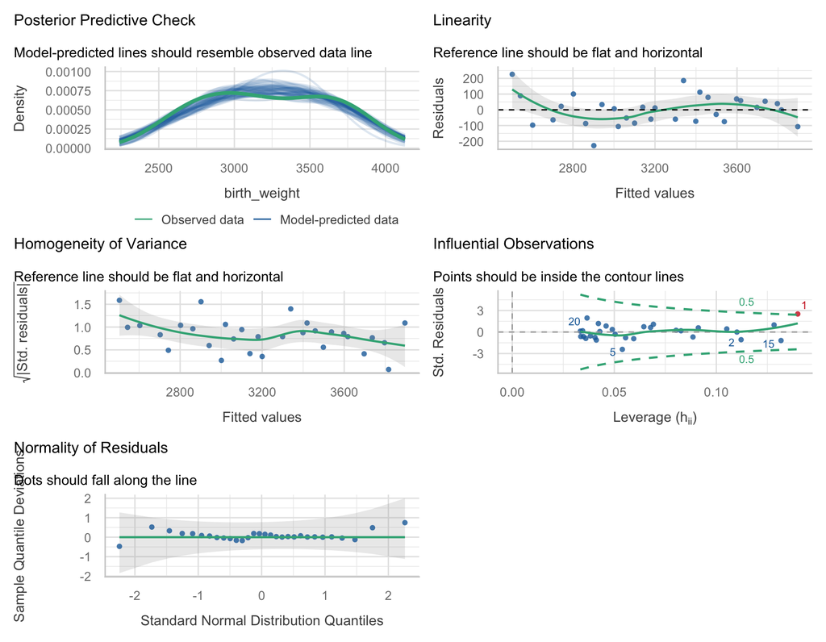

```r
check_model(practice_4_model)
```

**Your answer here:**

# Categorical polytomous predictor

A polytomous predictor has three or more levels (for example, three treatment groups).

Regression with one polytomous categorical predictor is the same model as a **one-way ANOVA**. The model is just comparing group means.

That means the assumptions are the same ones you learned for ANOVA:

- observations are independent
- each group’s residuals are roughly normal
- the groups have similar spread

In this lesson, `check_model()` helps us check the last two: **normality of residuals** and **homogeneity of variance**.

The fitted line connects the group means. Within each group, every observation has the same x-value (its group code).

**Shape (linearity)** is not a meaningful check here. The line passes through the group means, so there is no curvature to assess.

**Influential points** are not meaningful either. Every observation in a group shares the same x-value, so no point can have unusual leverage. A large outcome value is an outlier, not an influential point in the sense used above.

Only **H** (homogeneity of variance) and **N** (normality of residuals) apply.

With three or more groups, the homogeneity panel in `check_model()` behaves as expected.

The Linearity and Influential observations panels still appear in the default output, but you can hide them with the `check` argument. For example, `check = c("homogeneity", "normality")` shows only the two panels you need.